# Risk Factor Analysis

## Outcome Variable

**Outcome Variable:** ever_stunted

## Predictor Variables

**Intervention Variable:** enstunt

**Adjustment Set:**

unadjusted

## Stratifying Variables

The analysis was stratified on these variable(s):

- agecat
- studyid

The following strata were considered:

- agecat: 12 months, studyid: ki1000108-CMC-V-BCS-2002
- agecat: 12 months, studyid: ki1000108-IRC
- agecat: 12 months, studyid: ki1000109-EE
- agecat: 12 months, studyid: ki1000109-ResPak
- agecat: 12 months, studyid: ki1000304b-SAS-CompFeed
- agecat: 12 months, studyid: ki1000304b-SAS-FoodSuppl
- agecat: 12 months, studyid: ki1017093-NIH-Birth
- agecat: 12 months, studyid: ki1017093c-NIH-Crypto
- agecat: 12 months, studyid: ki1066203-TanzaniaChild2
- agecat: 12 months, studyid: ki1101329-Keneba
- agecat: 12 months, studyid: ki1112895-Guatemala BSC
- agecat: 12 months, studyid: ki1112895-iLiNS-Zinc
- agecat: 12 months, studyid: ki1113344-GMS-Nepal
- agecat: 12 months, studyid: ki1114097-CMIN
- agecat: 12 months, studyid: ki1114097-CONTENT
- agecat: 12 months, studyid: ki1119695-PROBIT
- agecat: 12 months, studyid: ki1126311-ZVITAMBO
- agecat: 12 months, studyid: ki1135781-COHORTS
- agecat: 12 months, studyid: ki1148112-LCNI-5
- agecat: 12 months, studyid: kiGH5241-JiVitA-3
- agecat: 12 months, studyid: kiGH5241-JiVitA-4
- agecat: 18 months, studyid: ki1000108-CMC-V-BCS-2002
- agecat: 18 months, studyid: ki1000108-IRC
- agecat: 18 months, studyid: ki1000109-EE
- agecat: 18 months, studyid: ki1000109-ResPak
- agecat: 18 months, studyid: ki1000304b-SAS-CompFeed
- agecat: 18 months, studyid: ki1000304b-SAS-FoodSuppl
- agecat: 18 months, studyid: ki1017093-NIH-Birth
- agecat: 18 months, studyid: ki1017093c-NIH-Crypto
- agecat: 18 months, studyid: ki1066203-TanzaniaChild2
- agecat: 18 months, studyid: ki1101329-Keneba
- agecat: 18 months, studyid: ki1112895-Guatemala BSC
- agecat: 18 months, studyid: ki1112895-iLiNS-Zinc
- agecat: 18 months, studyid: ki1113344-GMS-Nepal
- agecat: 18 months, studyid: ki1114097-CMIN
- agecat: 18 months, studyid: ki1114097-CONTENT
- agecat: 18 months, studyid: ki1119695-PROBIT
- agecat: 18 months, studyid: ki1126311-ZVITAMBO
- agecat: 18 months, studyid: ki1135781-COHORTS
- agecat: 18 months, studyid: ki1148112-LCNI-5
- agecat: 18 months, studyid: kiGH5241-JiVitA-3
- agecat: 18 months, studyid: kiGH5241-JiVitA-4
- agecat: 24 months, studyid: ki1000108-CMC-V-BCS-2002
- agecat: 24 months, studyid: ki1000108-IRC
- agecat: 24 months, studyid: ki1000109-EE
- agecat: 24 months, studyid: ki1000304b-SAS-CompFeed
- agecat: 24 months, studyid: ki1000304b-SAS-FoodSuppl
- agecat: 24 months, studyid: ki1017093-NIH-Birth
- agecat: 24 months, studyid: ki1017093c-NIH-Crypto
- agecat: 24 months, studyid: ki1066203-TanzaniaChild2
- agecat: 24 months, studyid: ki1101329-Keneba
- agecat: 24 months, studyid: ki1112895-iLiNS-Zinc
- agecat: 24 months, studyid: ki1113344-GMS-Nepal
- agecat: 24 months, studyid: ki1114097-CMIN
- agecat: 24 months, studyid: ki1114097-CONTENT
- agecat: 24 months, studyid: ki1119695-PROBIT
- agecat: 24 months, studyid: ki1126311-ZVITAMBO
- agecat: 24 months, studyid: ki1135781-COHORTS
- agecat: 24 months, studyid: ki1148112-LCNI-5
- agecat: 24 months, studyid: kiGH5241-JiVitA-3
- agecat: 24 months, studyid: kiGH5241-JiVitA-4
- agecat: 3 months, studyid: ki1000108-CMC-V-BCS-2002
- agecat: 3 months, studyid: ki1000108-IRC
- agecat: 3 months, studyid: ki1000109-EE
- agecat: 3 months, studyid: ki1000109-ResPak
- agecat: 3 months, studyid: ki1000304b-SAS-CompFeed
- agecat: 3 months, studyid: ki1017093-NIH-Birth
- agecat: 3 months, studyid: ki1017093c-NIH-Crypto
- agecat: 3 months, studyid: ki1066203-TanzaniaChild2
- agecat: 3 months, studyid: ki1101329-Keneba
- agecat: 3 months, studyid: ki1113344-GMS-Nepal
- agecat: 3 months, studyid: ki1114097-CMIN
- agecat: 3 months, studyid: ki1114097-CONTENT
- agecat: 3 months, studyid: ki1119695-PROBIT
- agecat: 3 months, studyid: ki1126311-ZVITAMBO
- agecat: 3 months, studyid: ki1135781-COHORTS
- agecat: 3 months, studyid: kiGH5241-JiVitA-3
- agecat: 3 months, studyid: kiGH5241-JiVitA-4
- agecat: 6 months, studyid: ki1000108-CMC-V-BCS-2002
- agecat: 6 months, studyid: ki1000108-IRC
- agecat: 6 months, studyid: ki1000109-EE
- agecat: 6 months, studyid: ki1000109-ResPak
- agecat: 6 months, studyid: ki1000304b-SAS-CompFeed
- agecat: 6 months, studyid: ki1000304b-SAS-FoodSuppl
- agecat: 6 months, studyid: ki1017093-NIH-Birth
- agecat: 6 months, studyid: ki1017093c-NIH-Crypto
- agecat: 6 months, studyid: ki1066203-TanzaniaChild2
- agecat: 6 months, studyid: ki1101329-Keneba
- agecat: 6 months, studyid: ki1112895-Guatemala BSC
- agecat: 6 months, studyid: ki1113344-GMS-Nepal
- agecat: 6 months, studyid: ki1114097-CMIN
- agecat: 6 months, studyid: ki1114097-CONTENT
- agecat: 6 months, studyid: ki1119695-PROBIT
- agecat: 6 months, studyid: ki1126311-ZVITAMBO
- agecat: 6 months, studyid: ki1135781-COHORTS
- agecat: 6 months, studyid: ki1148112-LCNI-5
- agecat: 6 months, studyid: kiGH5241-JiVitA-3
- agecat: 6 months, studyid: kiGH5241-JiVitA-4

## Methods Detail

# Results Detail

## Results Plots

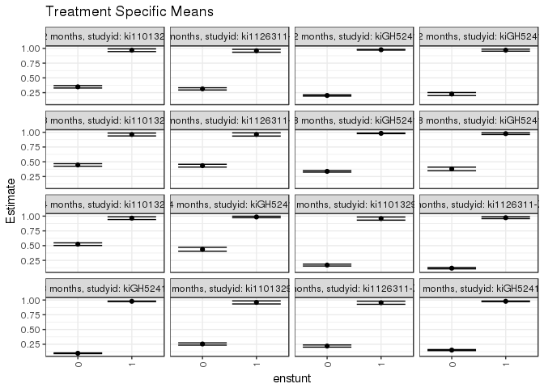

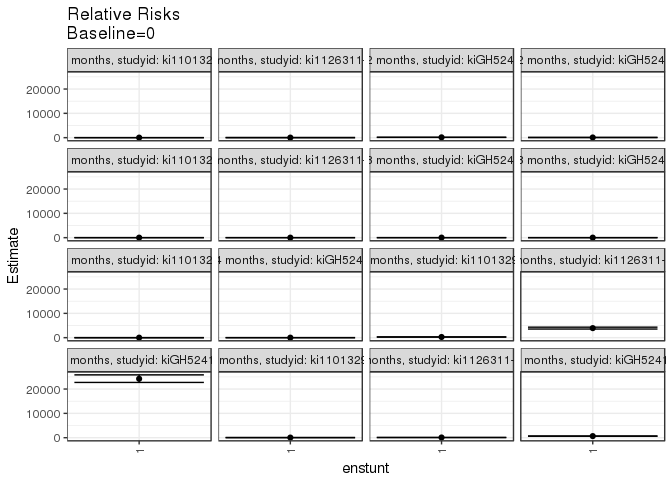

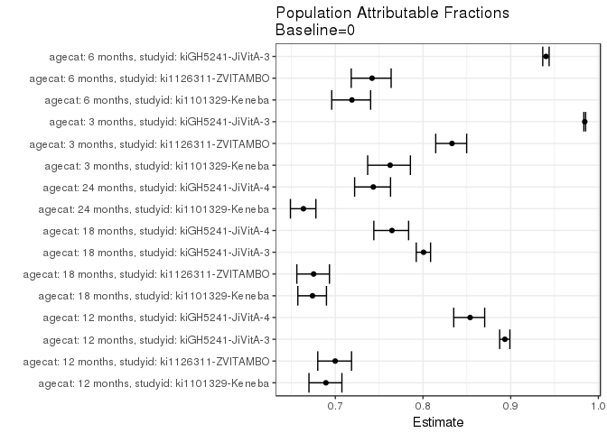

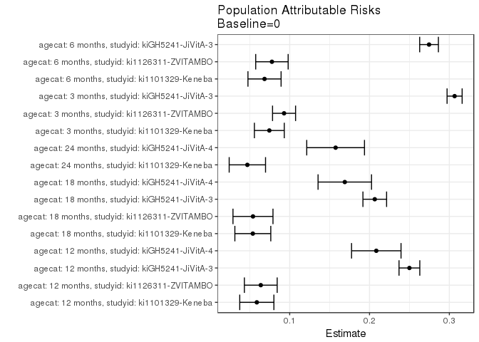

## Data Summary

| agecat | studyid | A | n | nA | nAY0 | nAY1 |
| --- | --- | --- | --- | --- | --- | --- |
| 12 months | ki1000108-CMC-V-BCS-2002 | 0 | 98 | 82 | 32 | 50 |
| 12 months | ki1000108-CMC-V-BCS-2002 | 1 | 98 | 16 | 0 | 16 |
| 12 months | ki1000108-IRC | 0 | 408 | 361 | 200 | 161 |
| 12 months | ki1000108-IRC | 1 | 408 | 47 | 1 | 46 |
| 12 months | ki1000109-EE | 0 | 373 | 245 | 65 | 180 |
| 12 months | ki1000109-EE | 1 | 373 | 128 | 0 | 128 |
| 12 months | ki1000109-ResPak | 0 | 72 | 56 | 20 | 36 |
| 12 months | ki1000109-ResPak | 1 | 72 | 16 | 0 | 16 |
| 12 months | ki1000304b-SAS-CompFeed | 0 | 889 | 644 | 369 | 275 |
| 12 months | ki1000304b-SAS-CompFeed | 1 | 889 | 245 | 1 | 244 |
| 12 months | ki1000304b-SAS-FoodSuppl | 0 | 96 | 57 | 15 | 42 |
| 12 months | ki1000304b-SAS-FoodSuppl | 1 | 96 | 39 | 0 | 39 |
| 12 months | ki1017093-NIH-Birth | 0 | 541 | 455 | 265 | 190 |
| 12 months | ki1017093-NIH-Birth | 1 | 541 | 86 | 0 | 86 |
| 12 months | ki1017093c-NIH-Crypto | 0 | 729 | 627 | 452 | 175 |
| 12 months | ki1017093c-NIH-Crypto | 1 | 729 | 102 | 0 | 102 |
| 12 months | ki1066203-TanzaniaChild2 | 0 | 5 | 5 | 2 | 3 |
| 12 months | ki1066203-TanzaniaChild2 | 1 | 5 | 0 | 0 | 0 |
| 12 months | ki1101329-Keneba | 0 | 2384 | 2158 | 1406 | 752 |
| 12 months | ki1101329-Keneba | 1 | 2384 | 226 | 7 | 219 |
| 12 months | ki1112895-Guatemala BSC | 0 | 85 | 63 | 48 | 15 |
| 12 months | ki1112895-Guatemala BSC | 1 | 85 | 22 | 0 | 22 |
| 12 months | ki1112895-iLiNS-Zinc | 0 | 796 | 627 | 625 | 2 |
| 12 months | ki1112895-iLiNS-Zinc | 1 | 796 | 169 | 0 | 169 |
| 12 months | ki1113344-GMS-Nepal | 0 | 582 | 518 | 317 | 201 |
| 12 months | ki1113344-GMS-Nepal | 1 | 582 | 64 | 0 | 64 |
| 12 months | ki1114097-CMIN | 0 | 2260 | 1960 | 1583 | 377 |
| 12 months | ki1114097-CMIN | 1 | 2260 | 300 | 0 | 300 |
| 12 months | ki1114097-CONTENT | 0 | 215 | 197 | 161 | 36 |
| 12 months | ki1114097-CONTENT | 1 | 215 | 18 | 0 | 18 |

[output cut: 180 more lines]

## Results Table

### Parameter: TSM

| agecat | studyid | intervention_level | baseline_level | estimate | ci_lower | ci_upper |
| --- | --- | --- | --- | --- | --- | --- |
| 12 months | ki1101329-Keneba | 0 | NA | 0.3484708 | 0.3283630 | 0.3685786 |
| 12 months | ki1101329-Keneba | 1 | NA | 0.9690265 | 0.9464349 | 0.9916182 |
| 12 months | ki1126311-ZVITAMBO | 0 | NA | 0.3136042 | 0.2944892 | 0.3327193 |
| 12 months | ki1126311-ZVITAMBO | 1 | NA | 0.9596774 | 0.9351899 | 0.9841650 |
| 12 months | kiGH5241-JiVitA-3 | 0 | NA | 0.2017977 | 0.1913542 | 0.2122411 |
| 12 months | kiGH5241-JiVitA-3 | 1 | NA | 0.9766839 | 0.9709936 | 0.9823742 |
| 12 months | kiGH5241-JiVitA-4 | 0 | NA | 0.2260274 | 0.2003755 | 0.2516793 |
| 12 months | kiGH5241-JiVitA-4 | 1 | NA | 0.9698492 | 0.9530434 | 0.9866551 |
| 18 months | ki1101329-Keneba | 0 | NA | 0.4457478 | 0.4242057 | 0.4672899 |
| 18 months | ki1101329-Keneba | 1 | NA | 0.9621849 | 0.9379457 | 0.9864240 |
| 18 months | ki1126311-ZVITAMBO | 0 | NA | 0.4334347 | 0.4094811 | 0.4573882 |
| 18 months | ki1126311-ZVITAMBO | 1 | NA | 0.9625668 | 0.9353530 | 0.9897807 |
| 18 months | kiGH5241-JiVitA-3 | 0 | NA | 0.3372140 | 0.3240855 | 0.3503425 |
| 18 months | kiGH5241-JiVitA-3 | 1 | NA | 0.9817021 | 0.9762829 | 0.9871213 |
| 18 months | kiGH5241-JiVitA-4 | 0 | NA | 0.3786802 | 0.3483775 | 0.4089830 |
| 18 months | kiGH5241-JiVitA-4 | 1 | NA | 0.9768041 | 0.9618211 | 0.9917872 |
| 24 months | ki1101329-Keneba | 0 | NA | 0.5248479 | 0.5028021 | 0.5468937 |
| 24 months | ki1101329-Keneba | 1 | NA | 0.9659574 | 0.9427673 | 0.9891475 |
| 24 months | kiGH5241-JiVitA-4 | 0 | NA | 0.4377934 | 0.4044667 | 0.4711201 |
| 24 months | kiGH5241-JiVitA-4 | 1 | NA | 0.9854651 | 0.9728126 | 0.9981176 |
| 3 months | ki1101329-Keneba | 0 | NA | 0.1702742 | 0.1541136 | 0.1864348 |
| 3 months | ki1101329-Keneba | 1 | NA | 0.9585253 | 0.9319911 | 0.9850595 |
| 3 months | ki1126311-ZVITAMBO | 0 | NA | 0.1176280 | 0.1062597 | 0.1289963 |
| 3 months | ki1126311-ZVITAMBO | 1 | NA | 0.9734043 | 0.9571387 | 0.9896698 |
| 3 months | kiGH5241-JiVitA-3 | 0 | NA | 0.0968445 | 0.0906351 | 0.1030539 |
| 3 months | kiGH5241-JiVitA-3 | 1 | NA | 0.9776488 | 0.9734013 | 0.9818964 |
| 6 months | ki1101329-Keneba | 0 | NA | 0.2544031 | 0.2355181 | 0.2732881 |
| 6 months | ki1101329-Keneba | 1 | NA | 0.9590909 | 0.9329107 | 0.9852711 |
| 6 months | ki1126311-ZVITAMBO | 0 | NA | 0.2194156 | 0.2013596 | 0.2374715 |
| 6 months | ki1126311-ZVITAMBO | 1 | NA | 0.9539749 | 0.9274037 | 0.9805461 |
| 6 months | kiGH5241-JiVitA-3 | 0 | NA | 0.1509669 | 0.1422034 | 0.1597304 |
| 6 months | kiGH5241-JiVitA-3 | 1 | NA | 0.9777290 | 0.9726064 | 0.9828516 |

### Parameter: E(Y)

| agecat | studyid | intervention_level | baseline_level | estimate | ci_lower | ci_upper |
| --- | --- | --- | --- | --- | --- | --- |
| 12 months | ki1101329-Keneba | NA | NA | 0.4072987 | 0.4000000 | 0.4145973 |
| 12 months | ki1126311-ZVITAMBO | NA | NA | 0.3773885 | 0.3698506 | 0.3849264 |
| 12 months | kiGH5241-JiVitA-3 | NA | NA | 0.4517670 | 0.4440091 | 0.4595249 |
| 12 months | kiGH5241-JiVitA-4 | NA | NA | 0.4345070 | 0.4171249 | 0.4518892 |
| 18 months | ki1101329-Keneba | NA | NA | 0.4995622 | 0.4930899 | 0.5060345 |
| 18 months | ki1126311-ZVITAMBO | NA | NA | 0.4874454 | 0.4801079 | 0.4947829 |
| 18 months | kiGH5241-JiVitA-3 | NA | NA | 0.5437807 | 0.5368958 | 0.5506655 |
| 18 months | kiGH5241-JiVitA-4 | NA | NA | 0.5477058 | 0.5334554 | 0.5619561 |
| 24 months | ki1101329-Keneba | NA | NA | 0.5718169 | 0.5661392 | 0.5774947 |
| 24 months | kiGH5241-JiVitA-4 | NA | NA | 0.5953177 | 0.5812620 | 0.6093734 |
| 3 months | ki1101329-Keneba | NA | NA | 0.2447735 | 0.2353393 | 0.2542078 |
| 3 months | ki1126311-ZVITAMBO | NA | NA | 0.2105719 | 0.2017009 | 0.2194429 |
| 3 months | kiGH5241-JiVitA-3 | NA | NA | 0.4034261 | 0.3963132 | 0.4105390 |
| 6 months | ki1101329-Keneba | NA | NA | 0.3228799 | 0.3142803 | 0.3314795 |
| 6 months | ki1126311-ZVITAMBO | NA | NA | 0.2971656 | 0.2878427 | 0.3064886 |
| 6 months | kiGH5241-JiVitA-3 | NA | NA | 0.4255208 | 0.4177315 | 0.4333102 |

### Parameter: RR

| agecat | studyid | intervention_level | baseline_level | estimate | ci_lower | ci_upper |
| --- | --- | --- | --- | --- | --- | --- |
| 12 months | ki1101329-Keneba | 1 | 0 | 16.131872 | 15.158513 | 17.167732 |
| 12 months | ki1126311-ZVITAMBO | 1 | 0 | 21.330852 | 19.966909 | 22.787965 |
| 12 months | kiGH5241-JiVitA-3 | 1 | 0 | 126.458822 | 120.041527 | 133.219178 |
| 12 months | kiGH5241-JiVitA-4 | 1 | 0 | 73.028384 | 65.107701 | 81.912657 |
| 18 months | ki1101329-Keneba | 1 | 0 | 8.658883 | 8.199605 | 9.143887 |
| 18 months | ki1126311-ZVITAMBO | 1 | 0 | 9.214597 | 8.659980 | 9.804734 |
| 18 months | kiGH5241-JiVitA-3 | 1 | 0 | 18.379102 | 17.670430 | 19.116197 |
| 18 months | kiGH5241-JiVitA-4 | 1 | 0 | 13.190490 | 12.158364 | 14.310235 |
| 24 months | ki1101329-Keneba | 1 | 0 | 6.299386 | 6.001872 | 6.611649 |
| 24 months | kiGH5241-JiVitA-4 | 1 | 0 | 9.497057 | 8.791475 | 10.259267 |
| 3 months | ki1101329-Keneba | 1 | 0 | 278.468684 | 252.255312 | 307.406046 |
| 3 months | ki1126311-ZVITAMBO | 1 | 0 | 3925.609667 | 3558.865619 | 4330.146993 |
| 3 months | kiGH5241-JiVitA-3 | 1 | 0 | 24222.445985 | 22714.773269 | 25830.189127 |
| 6 months | ki1101329-Keneba | 1 | 0 | 43.378547 | 40.079810 | 46.948784 |
| 6 months | ki1126311-ZVITAMBO | 1 | 0 | 77.308182 | 70.875360 | 84.324864 |
| 6 months | kiGH5241-JiVitA-3 | 1 | 0 | 649.656958 | 612.874036 | 688.647483 |

### Parameter: PAR

| agecat | studyid | intervention_level | baseline_level | estimate | ci_lower | ci_upper |
| --- | --- | --- | --- | --- | --- | --- |
| 12 months | ki1101329-Keneba | 0 | NA | 0.0588279 | 0.0374365 | 0.0802192 |
| 12 months | ki1126311-ZVITAMBO | 0 | NA | 0.0637843 | 0.0432367 | 0.0843319 |
| 12 months | kiGH5241-JiVitA-3 | 0 | NA | 0.2499693 | 0.2369596 | 0.2629789 |
| 12 months | kiGH5241-JiVitA-4 | 0 | NA | 0.2084796 | 0.1774932 | 0.2394661 |
| 18 months | ki1101329-Keneba | 0 | NA | 0.0538144 | 0.0313209 | 0.0763078 |
| 18 months | ki1126311-ZVITAMBO | 0 | NA | 0.0540108 | 0.0289586 | 0.0790630 |
| 18 months | kiGH5241-JiVitA-3 | 0 | NA | 0.2065667 | 0.1917425 | 0.2213910 |
| 18 months | kiGH5241-JiVitA-4 | 0 | NA | 0.1690256 | 0.1355393 | 0.2025118 |
| 24 months | ki1101329-Keneba | 0 | NA | 0.0469691 | 0.0242039 | 0.0697343 |
| 24 months | kiGH5241-JiVitA-4 | 0 | NA | 0.1575243 | 0.1213548 | 0.1936938 |
| 3 months | ki1101329-Keneba | 0 | NA | 0.0744993 | 0.0557865 | 0.0932122 |
| 3 months | ki1126311-ZVITAMBO | 0 | NA | 0.0929439 | 0.0785241 | 0.1073638 |
| 3 months | kiGH5241-JiVitA-3 | 0 | NA | 0.3065816 | 0.2971397 | 0.3160235 |
| 6 months | ki1101329-Keneba | 0 | NA | 0.0684767 | 0.0477259 | 0.0892275 |
| 6 months | ki1126311-ZVITAMBO | 0 | NA | 0.0777501 | 0.0574293 | 0.0980708 |
| 6 months | kiGH5241-JiVitA-3 | 0 | NA | 0.2745539 | 0.2628290 | 0.2862788 |

### Parameter: PAF

| agecat | studyid | intervention_level | baseline_level | estimate | ci_lower | ci_upper |
| --- | --- | --- | --- | --- | --- | --- |
| 12 months | ki1101329-Keneba | 0 | NA | 0.6892657 | 0.6699120 | 0.7074847 |
| 12 months | ki1126311-ZVITAMBO | 0 | NA | 0.6998254 | 0.6799408 | 0.7184747 |
| 12 months | kiGH5241-JiVitA-3 | 0 | NA | 0.8934043 | 0.8874306 | 0.8990610 |
| 12 months | kiGH5241-JiVitA-4 | 0 | NA | 0.8537393 | 0.8350364 | 0.8703217 |
| 18 months | ki1101329-Keneba | 0 | NA | 0.6739577 | 0.6572294 | 0.6898697 |
| 18 months | ki1126311-ZVITAMBO | 0 | NA | 0.6752212 | 0.6560755 | 0.6933012 |
| 18 months | kiGH5241-JiVitA-3 | 0 | NA | 0.8006252 | 0.7922935 | 0.8086226 |
| 18 months | kiGH5241-JiVitA-4 | 0 | NA | 0.7645730 | 0.7439055 | 0.7835725 |
| 24 months | ki1101329-Keneba | 0 | NA | 0.6636123 | 0.6487753 | 0.6778225 |
| 24 months | kiGH5241-JiVitA-4 | 0 | NA | 0.7432915 | 0.7219940 | 0.7629575 |
| 3 months | ki1101329-Keneba | 0 | NA | 0.7624853 | 0.7368653 | 0.7856109 |
| 3 months | ki1126311-ZVITAMBO | 0 | NA | 0.8330651 | 0.8145041 | 0.8497688 |
| 3 months | kiGH5241-JiVitA-3 | 0 | NA | 0.9844813 | 0.9834143 | 0.9854797 |
| 6 months | ki1101329-Keneba | 0 | NA | 0.7189341 | 0.6958701 | 0.7402491 |
| 6 months | ki1126311-ZVITAMBO | 0 | NA | 0.7418852 | 0.7181224 | 0.7636448 |
| 6 months | kiGH5241-JiVitA-3 | 0 | NA | 0.9403127 | 0.9365669 | 0.9438373 |